# Credit Card Users Churn Prediction

### Attrition_Flag vs Months_on_book

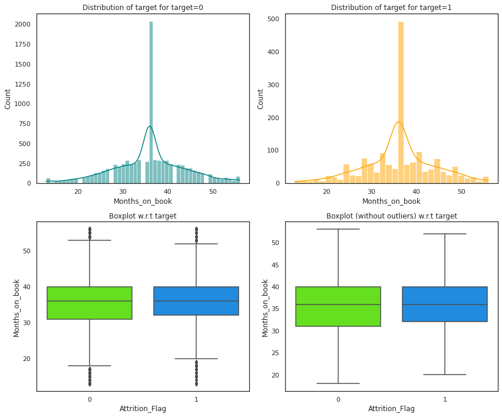

```python
distribution_plot_wrt_target(ccardDf, "Months_on_book", "Attrition_Flag")
```

- There is no major impact on attrition and how long the customers are with the bank.

### Attrition_Flag vs Credit_Limit

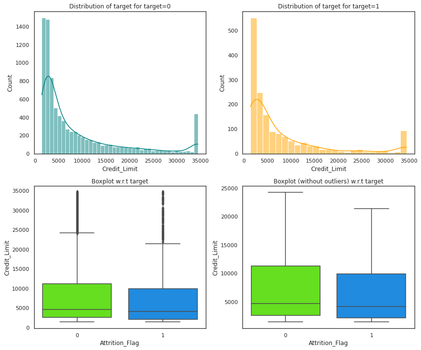

```python
distribution_plot_wrt_target(ccardDf, "Credit_Limit", "Attrition_Flag")
```

- Customers with lower credit limits are the ones who attrited.

### Attrition_Flag vs Total_Revolving_Bal

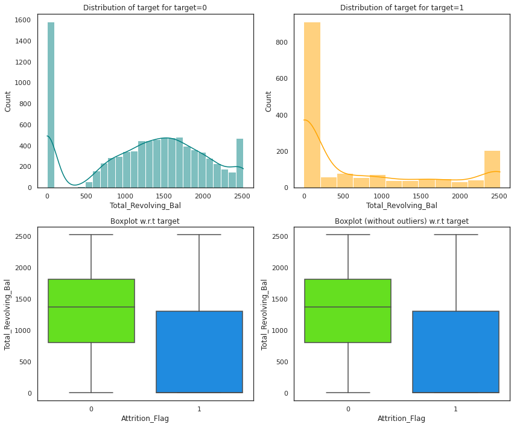

```python
distribution_plot_wrt_target(ccardDf, "Total_Revolving_Bal", "Attrition_Flag")
```

- Customers with less total revolving balance are the ones who attrited, such customers must have cleared their dues and opted out of the credit card service.

### Attrition_Flag vs Avg_Open_To_Buy

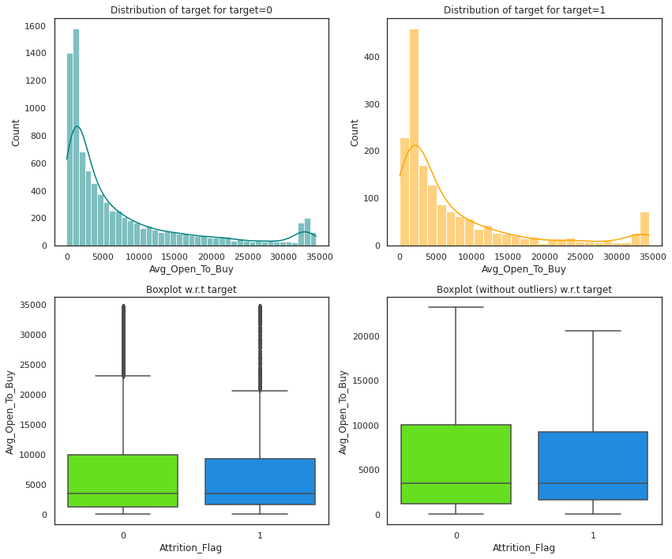

```python
distribution_plot_wrt_target(ccardDf, "Avg_Open_To_Buy", "Attrition_Flag")
```

- There's not much difference in the distribution for an attrited and existing customer.

### Attrition_Flag vs Total_Trans_Ct

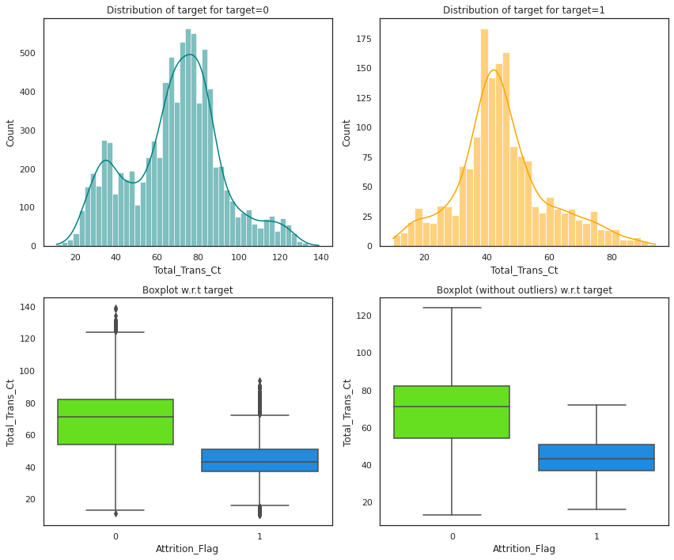

```python
distribution_plot_wrt_target(ccardDf, "Total_Trans_Ct", "Attrition_Flag")
```

- Less number of transactions lead to higher attrition.
- Customers with less than 80 to 100 transactions (or median transactions equal to 40) in a year should be more focused upon.

### Attrition_Flag vs Total_Trans_Amt

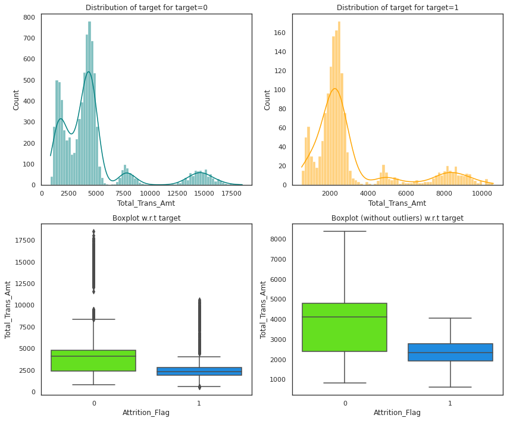

```python
distribution_plot_wrt_target(ccardDf, "Total_Trans_Amt", "Attrition_Flag")
```

- Less number of transactions might lead to a less transaction amount and eventually leading to customer attrition.

### Attrition_Flag vs Total_Amt_Chng_Q4_Q1

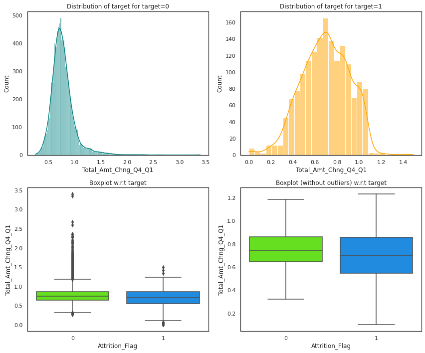

```python
distribution_plot_wrt_target(ccardDf, "Total_Amt_Chng_Q4_Q1", "Attrition_Flag")
```

- Customers who didn't attrite showed less variability across Q4 to Q1 as compared to the ones who attrited.

### Attrition_Flag vs Total_Ct_Chng_Q4_Q1

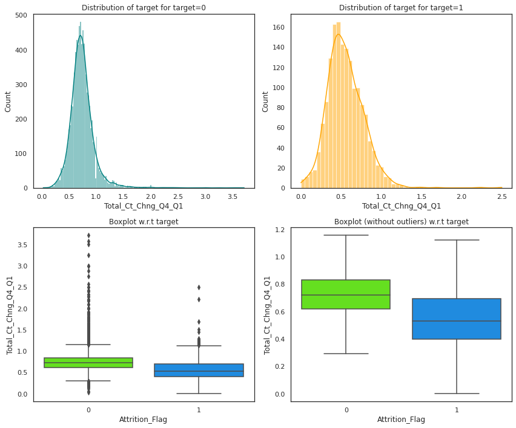

```python
distribution_plot_wrt_target(ccardDf, "Total_Ct_Chng_Q4_Q1", "Attrition_Flag")
```

- Customers who didn't attrite showed less variability across Q4 to Q1 as compared to the ones who attrited.